# UPI Tran. Project

#### *Project Title-"Digital Payment Analysis and UPI Transaction System"*

```python
import pandas as pd
import numpy as np
import seaborn as sns
import matplotlib.pyplot as plt
import scipy
import warnings
warnings.filterwarnings("ignore")
```

#### **Business Problem Understanding**

- To analyze the behaviour of Transactions of all private and Public sector Bank
- for better payment service of UPI Transactions

**Objectives :-**

- Which age group citizen make more transcations and less.
- Which bank receives and sends max. UPI Transactions and which minimun.
- In which time transactions is more or less.

**Load the dataset**

```python
df=pd.read_excel("UPI transactions.xlsx")
df.head()
```

|  | Date (dd/mm/yyyy) | Time | Transaction (thousands) | Sent From Bank | City | Age | Gender | Bank Received | Balance (thousands) | Customer ID | Age Groups |
| --- | --- | --- | --- | --- | --- | --- | --- | --- | --- | --- | --- |
| 0 | 2023-06-30 | 1:22:34 | 643.714122 | Axis Bank | Mumbai | 71 | Male | Bank of India | 484.504798 | 11 | Senior Adult |
| 1 | 2023-08-10 | 10:37:27 | 198.788436 | Axis Bank | Hyderabad | 83 | Female | Bandhan Bank | 981.841670 | 12 | Senior Adult |
| 2 | 2022-01-21 | 9:59:33 | 369.966567 | Axis Bank | Mumbai | 69 | Male | ICICI | 681.097801 | 22 | Senior Adult |
| 3 | 2023-09-11 | 2:47:45 | 288.951851 | Axis Bank | Bangalore | 78 | Male | Bank of India | 236.090819 | 10 | Senior Adult |
| 4 | 2023-07-14 | 6:43:18 | 698.746405 | Axis Bank | Delhi | 69 | Male | Bandhan Bank | 765.327698 | 17 | Senior Adult |

#### **Data Understanding And Data Exploration**

**To the First five rows of the dataset**

```python
df.head()
```

|  | Date (dd/mm/yyyy) | Time | Transaction (thousands) | Sent From Bank | City | Age | Gender | Bank Received | Balance (thousands) | Customer ID | Age Groups |
| --- | --- | --- | --- | --- | --- | --- | --- | --- | --- | --- | --- |
| 0 | 2023-06-30 | 1:22:34 | 643.714122 | Axis Bank | Mumbai | 71 | Male | Bank of India | 484.504798 | 11 | Senior Adult |
| 1 | 2023-08-10 | 10:37:27 | 198.788436 | Axis Bank | Hyderabad | 83 | Female | Bandhan Bank | 981.841670 | 12 | Senior Adult |
| 2 | 2022-01-21 | 9:59:33 | 369.966567 | Axis Bank | Mumbai | 69 | Male | ICICI | 681.097801 | 22 | Senior Adult |
| 3 | 2023-09-11 | 2:47:45 | 288.951851 | Axis Bank | Bangalore | 78 | Male | Bank of India | 236.090819 | 10 | Senior Adult |
| 4 | 2023-07-14 | 6:43:18 | 698.746405 | Axis Bank | Delhi | 69 | Male | Bandhan Bank | 765.327698 | 17 | Senior Adult |

**To the Last five rows of the dataset**

```python
df.tail()
```

|  | Date (dd/mm/yyyy) | Time | Transaction (thousands) | Sent From Bank | City | Age | Gender | Bank Received | Balance (thousands) | Customer ID | Age Groups |
| --- | --- | --- | --- | --- | --- | --- | --- | --- | --- | --- | --- |
| 2995 | 2022-05-09 | 6:9:57 | 267.617823 | Union Bank | Delhi | 17 | Female | ICICI | 896.352820 | 4 | Teen |
| 2996 | 2022-12-08 | 1:43:49 | 587.781140 | KreditBee | Bangalore | 17 | Male | Bank of Baroda | 590.202647 | 2 | Teen |
| 2997 | 2023-06-01 | 3:3:46 | 858.627031 | KreditBee | Delhi | 17 | Female | ICICI | 116.655068 | 20 | Teen |
| 2998 | 2023-01-17 | 1:27:33 | 666.802048 | Union Bank | Mumbai | 17 | Male | Bank of Baroda | 603.403235 | 2 | Teen |
| 2999 | 2023-09-05 | 11:51:3 | 329.419126 | ICICI | Chennai | 17 | Female | Bandhan Bank | 646.865141 | 13 | Teen |

#### **To know the number of rows and columns in the dataset**

```python
df.shape
```

```
(3000, 11)
```

**Observation :-There are 3000 Rows amd 11 columns in tis dataset**

#### **To know the names of columns in the dataset**

```python
df.columns
```

```
Index(['Date (dd/mm/yyyy)', 'Time', 'Transaction (thousands)',
       'Sent From Bank', 'City', 'Age', 'Gender', 'Bank Received ',
       'Balance (thousands)', 'Customer ID', 'Age Groups'],
      dtype='object')
```

```python
df.columns.tolist()
```

```
['Date (dd/mm/yyyy)',
 'Time',
 'Transaction (thousands)',
 'Sent From Bank',
 'City',
 'Age',
 'Gender',
 'Bank Received ',
 'Balance (thousands)',
 'Customer ID',
 'Age Groups']
```

#### **To know the Column Names,Count of Null Values,Data Types & Memory uses**

```python
df.info()
```

```
<class 'pandas.core.frame.DataFrame'>
RangeIndex: 3000 entries, 0 to 2999
Data columns (total 11 columns):
 #   Column                   Non-Null Count  Dtype
---  ------                   --------------  -----
 0   Date (dd/mm/yyyy)        3000 non-null   datetime64[ns]
 1   Time                     3000 non-null   object
 2   Transaction (thousands)  3000 non-null   float64
 3   Sent From Bank           3000 non-null   object
 4   City                     3000 non-null   object
 5   Age                      3000 non-null   int64
 6   Gender                   3000 non-null   object
 7   Bank Received            3000 non-null   object
 8   Balance (thousands)      3000 non-null   float64
 9   Customer ID              3000 non-null   int64
 10  Age Groups               3000 non-null   object
dtypes: datetime64[ns](1), float64(2), int64(2), object(6)
memory usage: 257.9+ KB
```

**Observation :-There is no missing values in any columns**

#### **To find missing values or null values in the dataset**

```python
df.isnull().sum()
```

```
Date (dd/mm/yyyy)          0
Time                       0
Transaction (thousands)    0
Sent From Bank             0
City                       0
Age                        0
Gender                     0
Bank Received              0
Balance (thousands)        0
Customer ID                0
Age Groups                 0
dtype: int64
```

**Observation :-There is no missing values in any columns**

#### **To find data types in the dataset**

```python
df.dtypes
```

```
Date (dd/mm/yyyy)          datetime64[ns]
Time                               object
Transaction (thousands)           float64
Sent From Bank                     object
City                               object
Age                                 int64
Gender                             object
Bank Received                      object
Balance (thousands)               float64
Customer ID                         int64
Age Groups                         object
dtype: object
```

**Observation :-**

- There is only one wrong datatype in time column.
- convert to part of datetime in month & year for better analyzing.

#### **To find the duplicate values in the dataset**

```python
df.duplicated().sum()
```

```
0
```

**Observation :-There is no duplicate values in this dataset**

```python
df.columns.tolist()
```

```
['Date (dd/mm/yyyy)',
 'Time',
 'Transaction (thousands)',
 'Sent From Bank',
 'City',
 'Age',
 'Gender',
 'Bank Received ',
 'Balance (thousands)',
 'Customer ID',
 'Age Groups']
```

#### **Analysing the each coulmns separately**

**1.Date (dd/mm/yyyy)**

#### **To know the all distinct values & datatypes from a specific column.**

```python
df['Date (dd/mm/yyyy)'].unique()
```

```
<DatetimeArray>
['2023-06-30 00:00:00', '2023-08-10 00:00:00', '2022-01-21 00:00:00',
 '2023-09-11 00:00:00', '2023-07-14 00:00:00', '2022-10-03 00:00:00',
 '2024-01-28 00:00:00', '2024-01-13 00:00:00', '2023-11-24 00:00:00',
 '2023-11-28 00:00:00',
 ...
 '2023-03-06 00:00:00', '2023-10-07 00:00:00', '2023-11-07 00:00:00',
 '2023-02-25 00:00:00', '2023-02-28 00:00:00', '2023-03-15 00:00:00',
 '2022-11-13 00:00:00', '2024-01-03 00:00:00', '2023-06-09 00:00:00',
 '2022-12-08 00:00:00']
Length: 749, dtype: datetime64[ns]
```

**Obervations:-**

#### **To know the number of distinct/unique values from a specific column.**

```python
df['Date (dd/mm/yyyy)'].nunique()    # count of the unique values
```

```
749
```

#### **2.Time**

**To know the all distinct values & datatypes from a specific column.**

```python
df['Time'].unique()
```

```
array(['1:22:34', '10:37:27', '9:59:33', ..., '3:3:46', '1:27:33',
       '11:51:3'], dtype=object)
```

**Obervations:-**

- It shows the time of transactions
- Data Types is wrong so we will have to change into correct Data Type i.e; datetime.
- convert to part of datetime for better understanding.

**To know the No. of distinct values from a specific column.**

```python
df['Time'].nunique()
```

```
2897
```

#### **3.Transaction (thousands)**

**To know the all distinct values & datatypes from a specific column.**

```python
df['Transaction (thousands)'].unique()
```

```
array([643.71412243, 198.78843565, 369.9665675 , ..., 858.62703052,
       666.80204755, 329.41912551])
```

**Obervations:-**

- It shows the transactions in indian repees

**To know the No. of distinct values from a specific column.**

```python
df['Transaction (thousands)'].nunique()
```

```
3000
```

#### **4.Sent From Bank**

**To know the all distinct values & datatypes from a specific column.**

```python
df['Sent From Bank'].unique()
```

```
array(['Axis Bank', 'KreditBee', 'HDFC', 'Union Bank', 'ICICI'],
      dtype=object)
```

**Obervations:-**

- It shows five bank name by which transactions has been sent to other bank

**To know the No. of distinct values from a specific column.**

```python
df['Sent From Bank'].nunique()
```

```
5
```

**To count the occurrences of the Unique values**

```python
df['Sent From Bank'].value_counts()
```

```
Sent From Bank
ICICI         624
Union Bank    613
Axis Bank     599
HDFC          586
KreditBee     578
Name: count, dtype: int64
```

**Observation:- ICICI bank has Maximun Transactions Sent**

```python
round(df['Sent From Bank'].value_counts()/len(df['Sent From Bank']),4)*100
```

```
Sent From Bank
ICICI         20.80
Union Bank    20.43
Axis Bank     19.97
HDFC          19.53
KreditBee     19.27
Name: count, dtype: float64
```

**Observation:- ICICI bank has done maximun Transactions but Union bank has almost similar Tr. to ICICI**

#### **5.City**

**To know the No. of distinct values from a specific column.**

```python
df['City'].nunique()
```

```
5
```

**To know the all distinct values & datatypes from a specific column.**

```python
df['City'].unique()
```

```
array(['Mumbai', 'Hyderabad', 'Bangalore', 'Delhi', 'Chennai'],
      dtype=object)
```

**Obervations:-**

- It shows five city names by which transactions has been done

**To count the occurrences of the Unique values**

```python
df['City'].value_counts()
```

```
City
Bangalore    616
Hyderabad    615
Delhi        600
Chennai      597
Mumbai       572
Name: count, dtype: int64
```

**Observation:-**

- Bangalore and Hyderabad has maximum Transactions
- Mumbai has mnimum Transactions

#### **6.Age**

**To know the all distinct values & datatypes from a specific column.**

```python
df['Age'].unique()
```

```
array([71, 83, 69, 78, 64, 62, 82, 72, 76, 84, 65, 61, 68, 77, 79, 74, 73,
       81, 66, 80, 75, 67, 60, 63, 70, 21, 22, 19, 29, 36, 34, 28, 18, 38,
       27, 39, 30, 32, 25, 31, 23, 20, 37, 24, 35, 26, 33, 52, 58, 54, 44,
       46, 41, 59, 42, 45, 55, 40, 51, 49, 47, 48, 53, 56, 57, 43, 50, 17],
      dtype=int64)
```

**Observation:-**

- It shows the unique age group persons

```python
df['Age'].mean()   # Average. Age
```

```
50.344
```

```python
df['Age'].max()   # Max. Age
```

```
84
```

```python
df['Age'].min()   # Min. Age
```

```
17
```

**Observation:-**

- It shows the maximum age people=84 years
- It shows the minimum age people=17 years
- It shows the average age of the people=50 years

#### **6.Gender**

**To know the all distinct values & datatypes from a specific column.**

```python
df['Gender'].unique()
```

```
array(['Male', 'Female'], dtype=object)
```

**Observation:- Male and Female**

**To count the occurrences of the Unique values**

```python
df['Gender'].value_counts()
```

```
Gender
Male      1514
Female    1486
Name: count, dtype: int64
```

**Observation:-**

- Maximun No. of Male does the transactions

#### **7.Bank Received**

```python
df.columns
```

```
Index(['Date (dd/mm/yyyy)', 'Time', 'Transaction (thousands)',
       'Sent From Bank', 'City', 'Age', 'Gender', 'Bank Received ',
       'Balance (thousands)', 'Customer ID', 'Age Groups'],
      dtype='object')
```

```python
# Here we need to replace 'Bank Received '(space) name with 'Bank Received'.

df.rename(columns={'Bank Received ':'Bank Received'},inplace=True)
```

**To know the No. of distinct values from a specific column.**

```python
df['Bank Received'].nunique()
```

```
8
```

**To know the all distinct values & datatypes from a specific column.**

```python
df['Bank Received'].unique()
```

```
array(['Bank of India', 'Bandhan Bank', 'ICICI', 'Axis Bank', 'HDFC',
       'Union Bank', 'KreditBee', 'Bank of Baroda'], dtype=object)
```

**Observation:- There are 8 Types of bank that receive UPI transactions**

**To count the occurrences of the Unique values**

```python
df['Bank Received'].value_counts()
```

```
Bank Received
HDFC              433
Axis Bank         400
Bandhan Bank      386
Bank of India     383
Union Bank        360
Bank of Baroda    349
ICICI             348
KreditBee         341
Name: count, dtype: int64
```

**Observation:-**

- There are 8 Types of bank that receive UPI transactions.
- In which HDFC receives more no. of Transactions that is approx similar to Axis Bank.

#### **8.Balance (thousands)**

**To know the all distinct values & datatypes from a specific column.**

```python
df['Balance (thousands)'].unique()
```

```
array([484.50479759, 981.84167013, 681.09780098, ..., 116.65506848,
       603.40323485, 646.86514058])
```

**Observation:-**

- It will show the all UPI Transactions Balance in Indian Rupees

**To know the No. of distinct values from a specific column.**

```python
df['Balance (thousands)'].nunique()
```

```
3000
```

#### **9.Customer ID**

**To know the No. of distinct values from a specific column.**

```python
df['Customer ID'].nunique()
```

```
22
```

**To know the all distinct values & datatypes from a specific column.**

```python
df['Customer ID'].unique()
```

```
array([11, 12, 22, 10, 17,  4,  6,  7, 21,  8, 20, 18, 15,  9, 19, 16, 13,
       14,  1,  3,  5,  2], dtype=int64)
```

**Observation:-**

- Here 22 Types of Unique Customer ID
- so only 22 types of Customers have done the UPI Transactions

**To count the occurrences of the Unique values**

```python
df['Customer ID'].value_counts()
```

```
Customer ID
2     163
16    160
17    150
8     146
15    146
20    145
7     143
5     142
18    142
19    138
1     138
21    136
12    135
3     131
9     130
22    130
14    128
10    126
4     122
11    119
6     118
13    112
Name: count, dtype: int64
```

**Observation:-**

- Here 22 Types of Unique Customer ID
- In which Customer ID has done max. UPI Transactions

#### **10.Age Groups**

**To know the No. of distinct values from a specific column.**

```python
df['Age Groups'].nunique()
```

```
4
```

**To know the all distinct values & datatypes from a specific column.**

```python
df['Age Groups'].unique()
```

```
array(['Senior Adult', 'Adult', 'Middle Age Adult', 'Teen'], dtype=object)
```

**Observation:-**

- Here 4 Types of Unique Age Groups(Citizens) have done the UPI Transactions

**To count the occurrences of the Unique values**

```python
df['Age Groups'].value_counts()
```

```
Age Groups
Senior Adult        1109
Adult               1007
Middle Age Adult     844
Teen                  40
Name: count, dtype: int64
```

**Observation:-**

- Here 4 Types of Unique Age Groups(Citizens) have done the UPI Transactions.
- In which Senior Adults have done Max. UPI Transactions.
- Teen has done Minimum Min. UPI Transactions.

**Conclusion:-**

- Time column-Change the wrong datatype(object) from write datatypes(datatime).
- continuous_variable=['Transaction (thousands)','Age','Balance (thousands)']
- timeseries_variable=['Date (dd/mm/yyyy)','Time']
- discreate_variable=['Sent From Bank','City','Gender','Bank Received','Customer ID','Age Groups']

```python
timeseries_variable=['Date (dd/mm/yyyy)','Time']
```

```python
continuous_variable=['Transaction (thousands)','Age','Balance (thousands)']
```

```python
discreate_variable=['Sent From Bank','City','Gender','Bank Received','Customer ID','Age Groups']
```

```python
# to check the outliers in df[continuous_variable]
```

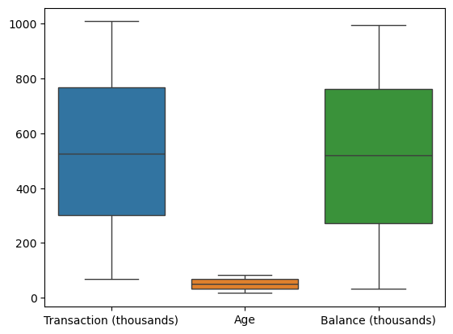

```python
sns.boxplot(df[continuous_variable])
plt.show()
```

**No outliers -'Transaction (thousands)' , 'Age' , & 'Balance (thousands)' so no need to treat them**

**To know the all descriptive statistical measures of continuous variable**

```python
df[continuous_variable].describe()
```

|  | Transaction (thousands) | Age | Balance (thousands) |
| --- | --- | --- | --- |
| count | 3000.000000 | 3000.000000 | 3000.000000 |
| mean | 533.791762 | 50.344000 | 515.370087 |
| std | 270.417288 | 19.725686 | 280.392138 |
| min | 68.032821 | 17.000000 | 34.135495 |
| 25% | 300.962858 | 33.000000 | 271.387805 |
| 50% | 525.320922 | 50.000000 | 519.442642 |
| 75% | 768.333817 | 68.000000 | 760.813343 |
| max | 1008.807429 | 84.000000 | 996.780463 |

#### **Observations:-**

**The average transaction amount is about 533 (in thousands)**

**The smallest transaction is about 68 (in thousands).**

**The largest transaction is about 1008 (in thousands).**

**The average age of customers is about 50 years.**

**The youngest customer is 17 years old.**

**The oldest customer is 84 years old.**

**The average balance is about 515 (in thousands)**

**The smallest balance is about 34 (in thousands).**

**The largest balance is about 996 (in thousands).**

**Brief descriptions about all discreate variable**

```python
df[discreate_variable].describe(include="object")
```

|  | Sent From Bank | City | Gender | Bank Received | Age Groups |
| --- | --- | --- | --- | --- | --- |
| count | 3000 | 3000 | 3000 | 3000 | 3000 |
| unique | 5 | 5 | 2 | 8 | 4 |
| top | ICICI | Bangalore | Male | HDFC | Senior Adult |
| freq | 624 | 616 | 1514 | 433 | 1109 |

**Observations**

- In Sent From Bank, ICICI Bank has done max no. of transactions out of 5.
- In Bank Received, HDFC Bank has done max no. of transactions out of 8.
- In City, Bangalore City has done max no. of transactions out of 5.
- In Gender, Male has done max no. of transactions out of 2.
- In Age Groups, Senior Adult has done max no. of transactions out of 4.

#### **Data processing**

**Here,we have created a new column for better understanding and analysing.**

**To create a new column as T year for Year in original dataset**

```python
df['T Year']=df['Date (dd/mm/yyyy)'].dt.year
```

**To create a new column as T Date for Day in original dataset**

```python
df['T Date']=df['Date (dd/mm/yyyy)'].dt.day
```

**To create a new column as T Month for Month in original dataset**

```python
df['T Month']=df['Date (dd/mm/yyyy)'].dt.month
```

**To create a new column as T Day for Day of the week by date in original dataset**

```python
df['T day']=df['Date (dd/mm/yyyy)'].dt.dayofweek
```

**To convert 0 with Mon,1 with Tue and so on - for better analysing & understanding**

```python
df['Day Name']=df['T day'].replace({0:'Mon',1:'Tue',2:'Wed',3:'Thu',4:'Fri',5:'Sat',6:'Sun',})
```

**To convert 1 with Jan ,2 with Feb ,3 with Mar and so on - for better analysing & understanding**

```python
df['Month Name'] = df['T Month'].replace({
    1: 'Jan', 2: 'Feb', 3: 'Mar', 4: 'Apr',
    5: 'May', 6: 'Jun', 7: 'Jul', 8: 'Aug',
    9: 'Sep', 10: 'Oct', 11: 'Nov', 12: 'Dec'
})
```

```python
df.shape
```

```
(3000, 17)
```

```python
df.columns
```

```
Index(['Date (dd/mm/yyyy)', 'Time', 'Transaction (thousands)',
       'Sent From Bank', 'City', 'Age', 'Gender', 'Bank Received',
       'Balance (thousands)', 'Customer ID', 'Age Groups', 'T Year', 'T Date',
       'T Month', 'T day', 'Day Name', 'Month Name'],
      dtype='object')
```

**To know the all distinct values & datatypes from a specific column.**

```python
df['T day'].unique()
```

```
array([4, 3, 0, 6, 5, 1, 2])
```

**Observations-It shows all days of the week as 0:Mon,1:Tue,2:Wed and so on**

```python
df['Day Name'].unique()
```

```
array(['Fri', 'Thu', 'Mon', 'Sun', 'Sat', 'Tue', 'Wed'], dtype=object)
```

**Observations-It shows all days of the week**

```python
df['Day Name'].value_counts()
```

```
Day Name
Fri    461
Tue    444
Sun    432
Thu    426
Mon    423
Sat    413
Wed    401
Name: count, dtype: int64
```

**Most Transactions has been done on Friday**

```python
df['T Month'].unique()
```

```
array([ 6,  8,  1,  9,  7, 10, 11,  2,  5,  3,  4, 12])
```

**Observations-It shows all Months as 1:Jan,2:Feb,3:Mar and so on**

```python
df['Month Name'].unique()
```

```
array(['Jun', 'Aug', 'Jan', 'Sep', 'Jul', 'Oct', 'Nov', 'Feb', 'May',
       'Mar', 'Apr', 'Dec'], dtype=object)
```

```python
df['Month Name'].value_counts()
```

```
Month Name
Jan    370
Aug    275
Jul    270
May    258
Dec    255
Sep    238
Apr    234
Jun    232
Mar    232
Oct    218
Nov    209
Feb    209
Name: count, dtype: int64
```

**Most Transactions has been done in January Month**

**Less Transactions has been done in February & november Month**

```python
df['T Year'].unique()
```

```
array([2023, 2022, 2024])
```

**Transactions Years**

```python
df['T Year'].value_counts()
```

```
T Year
2022    1454
2023    1423
2024     123
Name: count, dtype: int64
```

**Most Transactions has been done in year 2022**

**Less Transactions has been done in Year 2024**

**Trends of UPI Transactions is decreasing as year is increasing so it is an alarming conditions of Digital Payments**

#### **Data Analyzing and Visualization**

**Univariate analysis and visualizations**

**Sent From Bank**

```python
# which bank has done max. times and min. times transaction ?

df['Sent From Bank'].value_counts()
```

```
Sent From Bank
ICICI         624
Union Bank    613
Axis Bank     599
HDFC          586
KreditBee     578
Name: count, dtype: int64
```

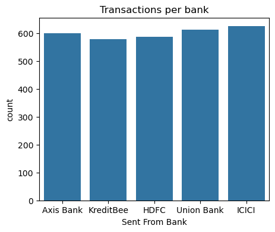

```python
# which bank has done max. times and min. times transaction ?

plt.figure(figsize=(5,4))
sns.countplot(x=df['Sent From Bank'])
plt.title("Transactions per bank")
plt.savefig("Sent From Bank")
plt.show()
```

**Obesrvations:-**

- ICICI bank has more Transactions and KreditBee has less Transactions

**City**

```python
# which city has done max. or min. Transactions?

df['City'].value_counts()
```

```
City
Bangalore    616
Hyderabad    615
Delhi        600
Chennai      597
Mumbai       572
Name: count, dtype: int64
```

**Obesrvations:-**

- Bangalore and Hyderabad have almost same Transactions which is max.
- Mumbai has less Transactions

```python
round(df['City'].value_counts()/len(df['City']),4)*100
```

```
City
Bangalore    20.53
Hyderabad    20.50
Delhi        20.00
Chennai      19.90
Mumbai       19.07
Name: count, dtype: float64
```

**Obesrvations:-**

- Bangalore and Hyderabad have almost same Transactions which is max.
- Mumbai has less Transactions

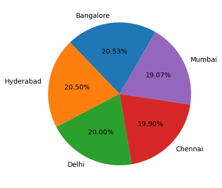

```python
a=df['City'].value_counts().index
b=df['City'].value_counts().values

plt.pie(b,labels=a,autopct="%0.2f%%",startangle=60)
plt.show()
```

**Obesrvations:-**

- Bangalore and Hyderabad have almost same Transactions which is max.
- Mumbai has less Transactions

**Gender**

```python
# who does the max. or min. Transactions either male or female?

df['Gender'].value_counts()
```

```
Gender
Male      1514
Female    1486
Name: count, dtype: int64
```

[figure not shown]

```python
plt.figure(figsize=(5,4))
sns.countplot(x=df['Gender'])
plt.title("Transactions per bank")
plt.savefig('Gender')
plt.show()
```

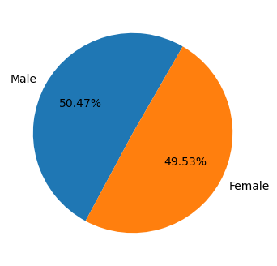

```python
a=df['Gender'].value_counts().index
b=df['Gender'].value_counts().values

plt.figure(figsize=(5,4))
plt.pie(b,labels=a,autopct="%0.2f%%",startangle=60)
plt.savefig("Gender")
plt.show()
```

**Observation:-Male does slightly more transactions than Female so no meaning**

#### **Bank Received**

```python
# which banks have revceived the max. or min. Transactions?

df['Bank Received'].value_counts()
```

```
Bank Received
HDFC              433
Axis Bank         400
Bandhan Bank      386
Bank of India     383
Union Bank        360
Bank of Baroda    349
ICICI             348
KreditBee         341
Name: count, dtype: int64
```

**Observation:-**

- HDFC Bank receives maximum transactions.
- KreditBee receives minimum transactions.

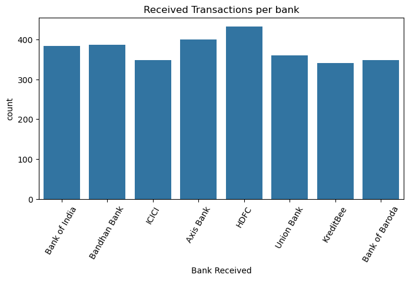

```python
plt.figure(figsize=(8,4))
sns.countplot(x=df['Bank Received'])
plt.title("Received Transactions per bank")
plt.xticks(rotation=60)
plt.savefig("Bank Received")
plt.show()
```

**Observation:-**

- HDFC Bank receives maximum transactions.
- KreditBee receives minimum transactions.

#### **Customer ID**

```python
df['Customer ID'].nunique()
```

```
22
```

```python
df['Customer ID'].value_counts()
```

```
Customer ID
2     163
16    160
17    150
8     146
15    146
20    145
7     143
5     142
18    142
19    138
1     138
21    136
12    135
3     131
9     130
22    130
14    128
10    126
4     122
11    119
6     118
13    112
Name: count, dtype: int64
```

**Observation:-**

- Maximum transactions has been done by customer id 2.
- Minimum transactions has been done by customer id 13.

#### **T Year**

```python
df['T Year'].unique()
```

```
array([2023, 2022, 2024])
```

```python
# In which year max.or min. UPI Transactions
# What is the trands of Transactions

df['T Year'].value_counts()
```

```
T Year
2022    1454
2023    1423
2024     123
Name: count, dtype: int64
```

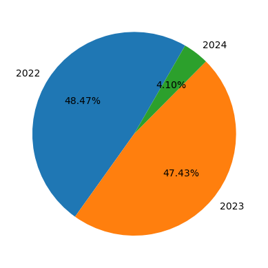

```python
a=df['T Year'].value_counts().index
b=df['T Year'].value_counts().values

plt.pie(b,labels=a,autopct="%0.2f%%",startangle=60)
plt.savefig("T Year")
plt.show()
```

#### **Observations:-**

**Max. transactions sent In year 2022**

**Min. transactions sent In year 2024**

**Year wise Transactions is decreasing**

#### **Age Groups**

```python
# Which age-group person is max. or min.
# Which age-group person did max. or min Transactions.


df['Age Groups'].value_counts()
```

```
Age Groups
Senior Adult        1109
Adult               1007
Middle Age Adult     844
Teen                  40
Name: count, dtype: int64
```

**Observation:-**

- Senior Adult age group person is Maximum.
- Teen age group person is Minimum.
- Maximum UPI Transactions have been done by Senior Adult, Adult and Middle Age Adult.
- Whereas Minimun UPI Transactions have been done by Teen.

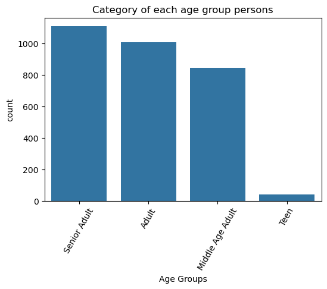

```python
plt.figure(figsize=(6,4))
sns.countplot(x=df['Age Groups'])
plt.title("Category of each age group persons")
plt.xticks(rotation=60)
plt.savefig('Age Groups')
plt.show()
```

**Observation:-**

- Senior Adult age group person is Maximum.
- Teen age group person is Minimum.
- Maximum UPI Transactions have been done by Senior Adult, Adult and Middle Age Adult.
- Whereas Minimun UPI Transactions have been done by Teen.

#### **Bivariate Analysis and Visualizations**

```python
# Which month avg. Transaction is max. or min  ?
# Monthly avg. Transaction ?

a=df.groupby('Month Name')['Transaction (thousands)'].mean()
print("Avg. Monthly trans. sent -",a)

b=df.groupby('Month Name')['Transaction (thousands)'].mean().min()
print("Minimum Monthly Trans. sent -",b)

e=df.groupby('Month Name')['Transaction (thousands)'].mean().max()
print("Maximum Monthly Trans. sent -",e)
```

```
Avg. Monthly trans. sent - Month Name
Apr    545.103650
Aug    534.660805
Dec    539.512509
Feb    505.042411
Jan    554.606815
Jul    552.954488
Jun    559.997464
Mar    541.855674
May    506.625340
Nov    502.825099
Oct    519.838738
Sep    522.701538
Name: Transaction (thousands), dtype: float64
Minimum Monthly Trans. sent - 502.8250992796405
Maximum Monthly Trans. sent - 559.997464174406
```

**Minimum Avg. Monthly Trans. sent - 503 in November month**

**Maximum Avg. Monthly Trans. sent - 560 in June month**

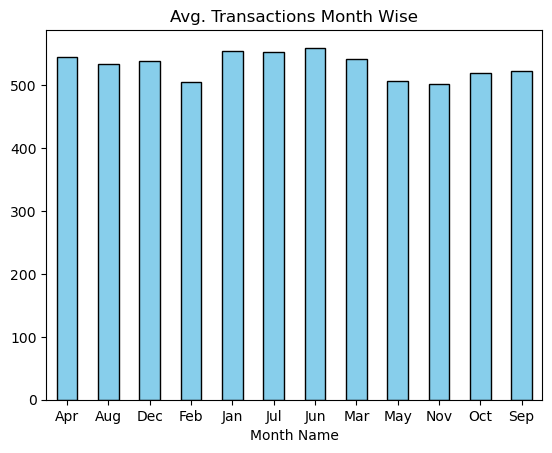

```python
a.plot(kind="bar",color="skyblue",edgecolor="black")
plt.title("Avg. Transactions Month Wise")
plt.xticks(rotation=0)
plt.savefig('Average Transactions Month Wise')
plt.show()
```

**Minimum Avg. Monthly Trans. sent - 503 in November month**

**Maximum Avg. Monthly Trans. sent - 560 in June month**

```python
# what is Day wise avg. Transactions?
#which Day avg.min. Transactions?
#which Day max. avg. Transactions?

b=df.groupby('Day Name')['Transaction (thousands)'].mean()
print("Day wise avg. Transactions",b)

c=df.groupby('Day Name')['Transaction (thousands)'].mean().min()
print("Day wise avg.min. Transactions",c)

d=df.groupby('Day Name')['Transaction (thousands)'].mean().max()
print("Day wise max. avg. Transactions",d)
```

```
Day wise avg. Transactions Day Name
Fri    557.209567
Mon    516.249609
Sat    533.707618
Sun    533.381940
Thu    545.822420
Tue    516.974212
Wed    531.743005
Name: Transaction (thousands), dtype: float64
Day wise avg.min. Transactions 516.249608624639
Day wise max. avg. Transactions 557.2095667588576
```

**Day wise max. avg. Transactions 557 on Fri.**

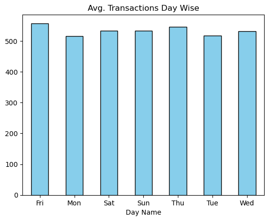

```python
b.plot(kind="bar",color="skyblue",edgecolor="black")
plt.title("Avg. Transactions Day Wise")
plt.xticks(rotation=0)
plt.savefig('Avg Transactions Day Wise')
plt.show()
```

**Day wise max. avg. Transactions 557 on Fri.**

```python
#Avg. Transactions of each year?
#Min. Avg. Transactions in which year?
# Max. Avg. Transactions in which year?



c=df.groupby('T Year')['Transaction (thousands)'].mean()
print('Avg. Transactions of each year',c)

e=df.groupby('T Year')['Transaction (thousands)'].mean().min()
print('Min. Avg. Transactions',e)

f=df.groupby('T Year')['Transaction (thousands)'].mean().max()
print('Max. Avg. Transactions',f)
```

```
Avg. Transactions of each year T Year
2022    539.626080
2023    526.680281
2024    547.096941
Name: Transaction (thousands), dtype: float64
Min. Avg. Transactions 526.6802811270184
Max. Avg. Transactions 547.096941244142
```

**Min. Avg. Transactions 526 in year 2023**

**Max. Avg. Transactions 547 in year 2024**

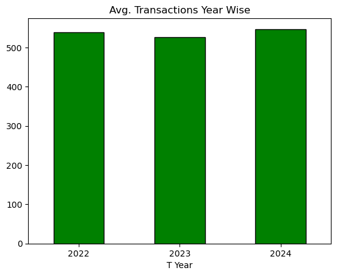

```python
c.plot(kind="bar",color="green",edgecolor="black")
plt.title("Avg. Transactions Year Wise")
plt.xticks(rotation=0)
plt.savefig("Avg Transactions Year Wise")
plt.show()
```

**Min. Avg. Transactions 526 in year 2023**

**Max. Avg. Transactions 547 in year 2024**

```python
#which gender done max. or min. avg. transactons?


df.groupby("Gender")['Transaction (thousands)'].mean()
```

```
Gender
Female    531.472044
Male      536.068578
Name: Transaction (thousands), dtype: float64
```

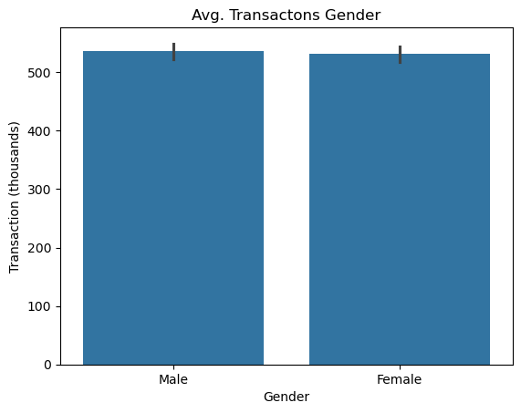

```python
sns.barplot(x="Gender",y="Transaction (thousands)",data=df)
plt.title("Avg. Transactons Gender")
plt.show()
```

**Male does slightly more transaction by Female so it doesnot affect the transction**

```python
#which bank sent max. or min. avg. transactons?


x=df.groupby("Sent From Bank")['Transaction (thousands)'].mean()
x
```

```
Sent From Bank
Axis Bank     530.369697
HDFC          524.275412
ICICI         533.282720
KreditBee     551.565300
Union Bank    529.992306
Name: Transaction (thousands), dtype: float64
```

**Max. Avg. Transactions sent by KreditBee**

**Min. Avg. Transactions sent by HDFC**

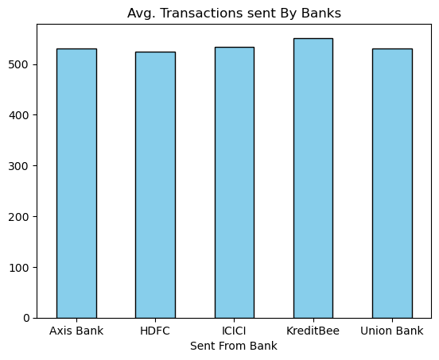

```python
x.plot(kind="bar",color="skyblue",edgecolor="black")
plt.title("Avg. Transactions sent By Banks")
plt.xticks(rotation=0)
plt.show()
```

**Max. Avg. Transactions sent by KreditBee**

**Min. Avg. Transactions sent by HDFC**

```python
#Avg. Transactions received by each bank?
#Min. Avg. Transactions received?
#Max.Avg. Transactions received?
s=df.groupby("Bank Received")['Transaction (thousands)'].mean()
s
```

```
Bank Received
Axis Bank         533.793879
Bandhan Bank      497.995993
Bank of Baroda    552.974673
Bank of India     515.910187
HDFC              526.443505
ICICI             532.384000
KreditBee         567.552512
Union Bank        550.817892
Name: Transaction (thousands), dtype: float64
```

**Min. Avg. Transactions received by Bandhan Bank**

**Max.Avg. Transactions received by KreditBee Bank**

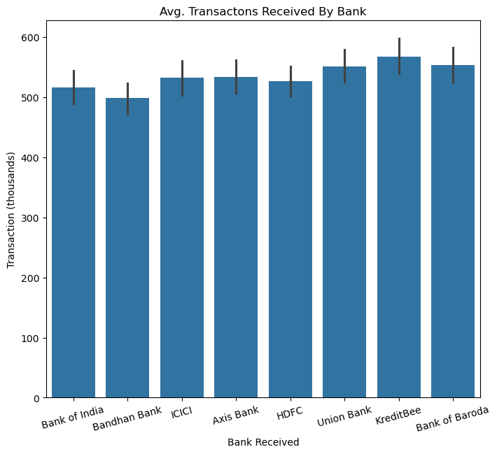

```python
plt.figure(figsize=(8,7))
sns.barplot(x="Bank Received",y="Transaction (thousands)",data=df)
plt.title("Avg. Transactons Received By Bank")
plt.xticks(rotation=15)
plt.show()
```

**Min. Avg. Transactions received by Bandhan Bank**

**Max.Avg. Transactions received by KreditBee Bank**

```python
#Max. money transformed in which city by which bank?

pd.crosstab(df['City'],df['Sent From Bank'],margins=1)
```

| Sent From Bank City | Axis Bank | HDFC | ICICI | KreditBee | Union Bank | All |
| --- | --- | --- | --- | --- | --- | --- |
| Bangalore | 121 | 117 | 127 | 115 | 136 | 616 |
| Chennai | 120 | 121 | 130 | 105 | 121 | 597 |
| Delhi | 130 | 108 | 121 | 134 | 107 | 600 |
| Hyderabad | 128 | 126 | 118 | 113 | 130 | 615 |
| Mumbai | 100 | 114 | 128 | 111 | 119 | 572 |
| All | 599 | 586 | 624 | 578 | 613 | 3000 |

**In Mumbai max. trans. done by ICICI Bank.**

**In Hyderabad max. trans. done by Union Bank.**

**In Chennai max. trans. done by ICICI Bank.**

**In Delhi max. trans. done by KreditBee Bank.**

**In Bangalore max. trans. done by Union Bank.**

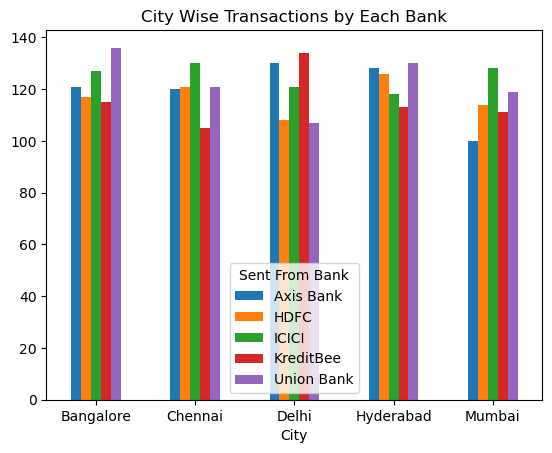

```python
# plt.figure(figsize=(20,10))
pd.crosstab(df['City'],df['Sent From Bank']).plot(kind="bar")
plt.title("City Wise Transactions by Each Bank")
plt.xticks(rotation=0)
plt.show()
```

**In Mumbai max. trans. done by ICICI Bank.**

**In Hyderabad max. trans. done by Union Bank.**

**In Chennai max. trans. done by ICICI Bank.**

**In Delhi max. trans. done by KreditBee Bank.**

**In Bangalore max. trans. done by Union Bank.**

```python
#Max. money received in which city by which bank?

pd.crosstab(df['City'],df['Bank Received'],margins=1)
```

| Bank Received City | Axis Bank | Bandhan Bank | Bank of Baroda | Bank of India | HDFC | ICICI | KreditBee | Union Bank | All |
| --- | --- | --- | --- | --- | --- | --- | --- | --- | --- |
| Bangalore | 78 | 66 | 75 | 76 | 93 | 85 | 66 | 77 | 616 |
| Chennai | 82 | 83 | 66 | 82 | 81 | 64 | 66 | 73 | 597 |
| Delhi | 82 | 82 | 77 | 82 | 81 | 60 | 74 | 62 | 600 |
| Hyderabad | 75 | 89 | 65 | 70 | 87 | 76 | 67 | 86 | 615 |
| Mumbai | 83 | 66 | 66 | 73 | 91 | 63 | 68 | 62 | 572 |
| All | 400 | 386 | 349 | 383 | 433 | 348 | 341 | 360 | 3000 |

**In Bangalore max. trans. received by HDFC Bank.**

**In Chennai max. trans. received by Bandhan Bank.**

**In Delhi max. trans. received by Axis Bank,Bandhan Bank & Bank of India.**

**In Hyderabad max. trans. received by Bandhan Bank.**

**In Mumbai max. trans. received by HDFC Bank.**

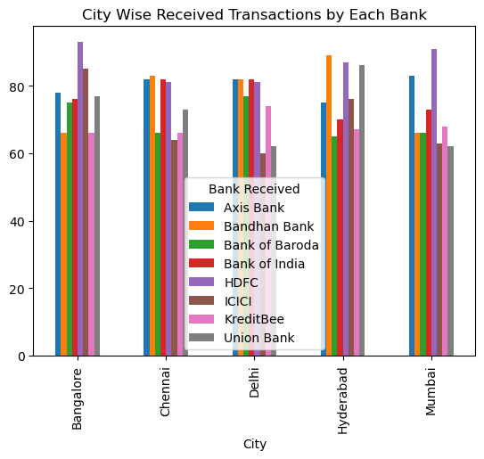

```python
pd.crosstab(df['City'],df['Bank Received']).plot(kind="bar")
plt.title("City Wise Received Transactions by Each Bank")
# plt.xticks(rotation=0)
plt.show()
```

**In Bangalore max. trans. received by HDFC Bank.**

**In Chennai max. trans. received by Bandhan Bank.**

**In Delhi max. trans. received by Axis Bank,Bandhan Bank & Bank of India.**

**In Hyderabad max. trans. received by Bandhan Bank.**

**In Mumbai max. trans. received by HDFC Bank.**

```python
#which age group persons are using which bank max. or min.?

pd.crosstab(df['Age Groups'],df['Sent From Bank'],margins=1)
```

| Sent From Bank Age Groups | Axis Bank | HDFC | ICICI | KreditBee | Union Bank | All |
| --- | --- | --- | --- | --- | --- | --- |
| Adult | 190 | 208 | 234 | 170 | 205 | 1007 |
| Middle Age Adult | 160 | 155 | 172 | 172 | 185 | 844 |
| Senior Adult | 245 | 217 | 208 | 228 | 211 | 1109 |
| Teen | 4 | 6 | 10 | 8 | 12 | 40 |
| All | 599 | 586 | 624 | 578 | 613 | 3000 |

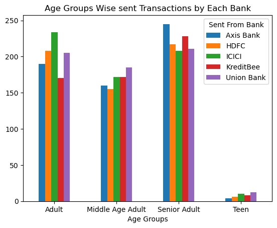

```python
pd.crosstab(df['Age Groups'],df['Sent From Bank']).plot(kind="bar")
plt.title("Age Groups Wise sent Transactions by Each Bank")
plt.xticks(rotation=0)
plt.show()
```

**Adults are using ICICI Bank the most and least KreditBee**

**Middle Age Adults are using Union Bank the most and least HDFC**

**Senior Adults are using Axis Bank the most and least ICICI**

**Teens are using Union Bank the most and least Axis bank**

```python
#which age group persons are using which bank max. or min.?

pd.crosstab(df['Age Groups'],df['Bank Received'],margins=1)
```

| Bank Received Age Groups | Axis Bank | Bandhan Bank | Bank of Baroda | Bank of India | HDFC | ICICI | KreditBee | Union Bank | All |
| --- | --- | --- | --- | --- | --- | --- | --- | --- | --- |
| Adult | 126 | 131 | 129 | 138 | 133 | 115 | 117 | 118 | 1007 |
| Middle Age Adult | 134 | 106 | 100 | 88 | 130 | 89 | 87 | 110 | 844 |
| Senior Adult | 136 | 143 | 117 | 151 | 167 | 136 | 130 | 129 | 1109 |
| Teen | 4 | 6 | 3 | 6 | 3 | 8 | 7 | 3 | 40 |
| All | 400 | 386 | 349 | 383 | 433 | 348 | 341 | 360 | 3000 |

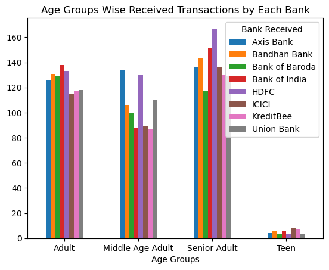

```python
pd.crosstab(df['Age Groups'],df['Bank Received']).plot(kind="bar")
plt.title("Age Groups Wise Received Transactions by Each Bank")
plt.xticks(rotation=0)
plt.show()
```

**Adults are using Bank of India the most and least ICICI**

**Middle Age Adults are using Axis Bank the most and least KreditBee**

**Senior Adults are using HDFC Bank the most and least Bank of Baroda**

**Teens are using ICICI Bank the most and least Union bank**

```python
#Min. Avg. Transactions by which age group?
#Max.Avg. Transactions by which age group?
df.groupby("Age Groups")['Transaction (thousands)'].mean()
```

```
Age Groups
Adult               525.862410
Middle Age Adult    545.222166
Senior Adult        533.366047
Teen                504.034601
Name: Transaction (thousands), dtype: float64
```

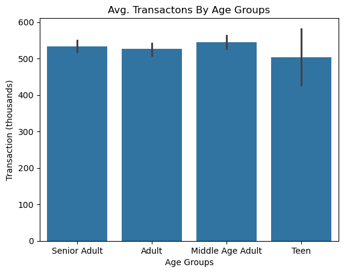

```python
# plt.figure(figsize=(8,7))
sns.barplot(x="Age Groups",y="Transaction (thousands)",data=df)
plt.title("Avg. Transactons By Age Groups")
# plt.xticks(rotation=15)
plt.show()
```

**Max. Transactions done by Middle Age Adult**

**Min. Transactions done by Teen Age Adult**

#### **Multivariate Analysis and Visualizations**

```python
#which age groups and city do highest or lowest avg. Transactions?

a=df.groupby(['Age Groups','City'])['Transaction (thousands)'].mean()
a
```

```
Age Groups        City
Adult             Bangalore    513.942037
                  Chennai      516.561417
                  Delhi        528.199853
                  Hyderabad    542.155816
                  Mumbai       528.244573
Middle Age Adult  Bangalore    560.240202
                  Chennai      551.698653
                  Delhi        532.175992
                  Hyderabad    504.903847
                  Mumbai       576.141944
Senior Adult      Bangalore    502.323111
                  Chennai      552.084574
                  Delhi        541.628651
                  Hyderabad    552.313538
                  Mumbai       517.658950
Teen              Bangalore    535.835062
                  Chennai      465.474412
                  Delhi        478.689969
                  Hyderabad    496.813794
                  Mumbai       547.277192
Name: Transaction (thousands), dtype: float64
```

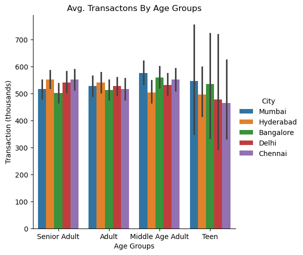

```python
sns.catplot(y="Transaction (thousands)",x="Age Groups",hue="City",data=df,kind="bar")
plt.title("Avg. Transactons By Age Groups")
plt.show()
```

**Senior Adult people do the max. trans. in Hyderabad and Min. in Bangalore**

**Adult people do the max. trans. in Hyderabad and Min. in Bangalore**

```python
#which T Year and which city do highest Transactions?

df.groupby(['T Year','City'])['Transaction (thousands)'].mean()
```

```
T Year  City
2022    Bangalore    515.775204
        Chennai      537.762501
        Delhi        558.549977
        Hyderabad    539.970760
        Mumbai       546.688030
2023    Bangalore    526.144529
        Chennai      542.556349
        Delhi        504.463746
        Hyderabad    527.955705
        Mumbai       533.108286
2024    Bangalore    591.177591
        Chennai      506.908527
        Delhi        577.482047
        Hyderabad    565.184530
        Mumbai       511.813531
Name: Transaction (thousands), dtype: float64
```

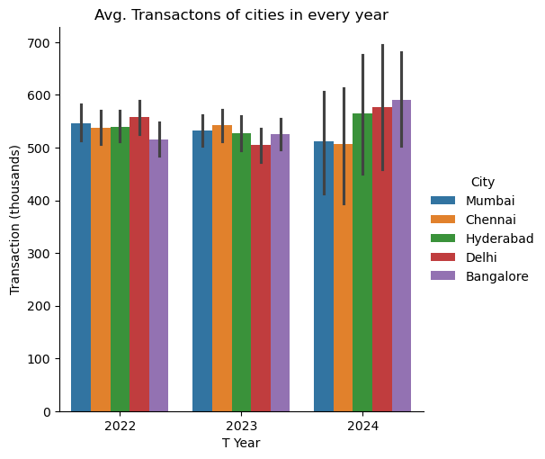

```python
sns.catplot(y="Transaction (thousands)",x="T Year",hue="City",data=df,kind="bar")
plt.title("Avg. Transactons of cities in every year")
plt.show()
```

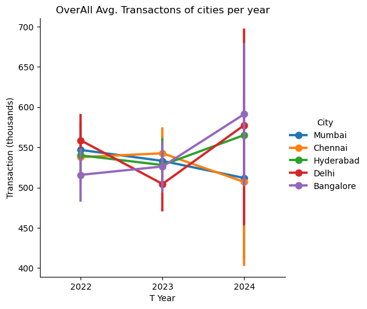

```python
# relationship among all over cities transactions are increasing or decreasing?

sns.catplot(y="Transaction (thousands)",x="T Year",hue="City",data=df,kind="point")
plt.title(" OverAll Avg. Transactons of cities per year ")
plt.show()
```

#### **Observations**

- Bangalore kept increasing each year from 2022 to 2024.
- Delhi dropped in 2023 but rose again in 2024.
- Chennai stayed almost the same or slightly decreased in 2024.
- Hyderabad went up or down at different times — check the exact values.
- Mumbai stayed steady or changed just a little.

```python
#Whether the  avg. transactions are increasing or decreasing every years for each bank?

df.groupby(['T Year','Sent From Bank'])['Transaction (thousands)'].mean()
```

```
T Year  Sent From Bank
2022    Axis Bank         547.999420
        HDFC              531.723434
        ICICI             538.429231
        KreditBee         562.091426
        Union Bank        518.829073
2023    Axis Bank         519.847155
        HDFC              520.426107
        ICICI             519.153568
        KreditBee         542.669232
        Union Bank        531.744975
2024    Axis Bank         452.157526
        HDFC              477.037536
        ICICI             616.428171
        KreditBee         526.553156
        Union Bank        649.569902
Name: Transaction (thousands), dtype: float64
```

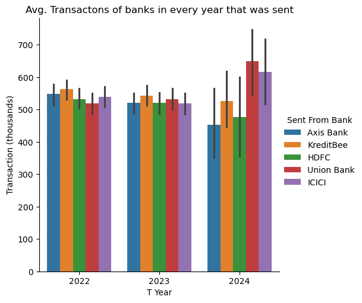

```python
sns.catplot(y="Transaction (thousands)",x="T Year",hue="Sent From Bank",data=df,kind="bar")
plt.title("Avg. Transactons of banks in every year that was sent")
plt.show()
```

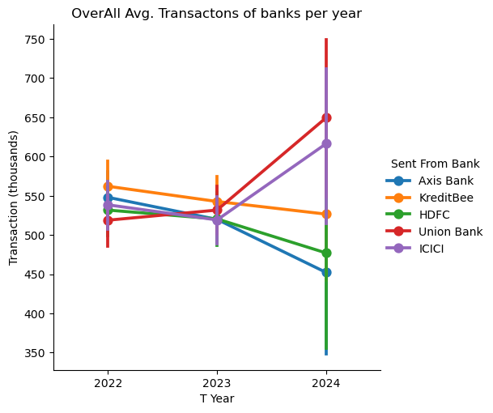

```python
# relationship among all over year transactions are increasing or decreasing that was sent?

sns.catplot(y="Transaction (thousands)",x="T Year",hue="Sent From Bank",data=df,kind="point")
plt.title(" OverAll Avg. Transactons of banks per year ")
plt.show()
```

**Union Bank and ICICI are growing in popularity for UPI transactions.**

**HDFC and Axis Bank are declining in transaction usage.**

**KreditBee maintains user base.**

```python
#Whether the transactions are increasing or decreasing over years that was received?

df.groupby(['T Year','Bank Received'])['Transaction (thousands)'].mean()
```

```
T Year  Bank Received
2022    Axis Bank         555.700000
        Bandhan Bank      492.425715
        Bank of Baroda    564.198796
        Bank of India     525.326085
        HDFC              530.615576
        ICICI             526.255016
        KreditBee         569.827503
        Union Bank        558.177940
2023    Axis Bank         512.887715
        Bandhan Bank      507.236290
        Bank of Baroda    528.780776
        Bank of India     501.804510
        HDFC              518.269667
        ICICI             537.623736
        KreditBee         558.912508
        Union Bank        553.735450
2024    Axis Bank         484.330756
        Bandhan Bank      435.867997
        Bank of Baroda    633.973004
        Bank of India     576.874716
        HDFC              563.315540
        ICICI             542.864813
        KreditBee         626.281157
        Union Bank        462.915492
Name: Transaction (thousands), dtype: float64
```

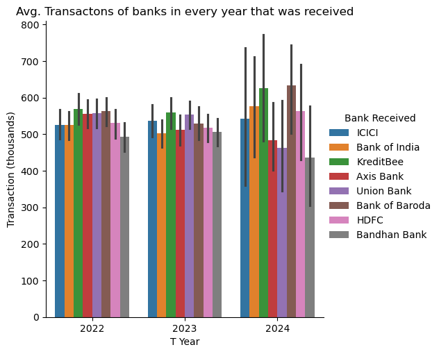

```python
sns.catplot(y="Transaction (thousands)",x="T Year",hue="Bank Received",data=df,kind="bar")
plt.title("Avg. Transactons of banks in every year that was received")
plt.show()
```

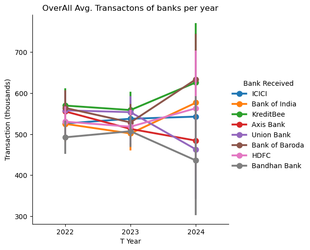

```python
# relationship among all over banks transactions are increasing or decreasing that eas receivedL?

sns.catplot(y="Transaction (thousands)",x="T Year",hue="Bank Received",data=df,kind="point")
plt.title(" OverAll Avg. Transactons of banks per year ")
plt.show()
```